# Contraste de dados sobre saúde e bem-estar antes e pós-pandemia

Análise exploratória dos dados da VIGITEL dos anos 2019 e 2023.

Author

Carolina Brito

## 1 Contexto

Para esse projeto eu decedi trabalhar com a base de dados da [**VIGITEL**](https://svs.aids.gov.br/daent/cgdnt/vigitel/) **(Vigilância de Fatores de Risco e Proteção para Doenças Crônicas por Inquerito Telefônico)** é uma edição anual de pesquisa telefônica realizada pelo Ministério da Saúde do Brasil desde 2006. Monitora fatores de risco e proteção para doenças crônicas não transmissíveis entre adultos (18+) em todas as 26 capitais estaduais e o Distrito Federal.Por ela ter uma grande quantidade de dados,foi usado o pacote `healthbR` no R para importar as variáveis desejadas. [^1]

Dentre os anos disponíveis foi escolhido os anos de 2019(52.443 entrevistados) e 2023(21.600 entrevistados) com o **objetivo de comparar os dados antes da pandemia e pós-pandemia, com variáveis relacionadas a saúde e bem-estar da população dos entrevistados.**Dentre as variáveis disponíveis foram escolhidas: doenças crônicas(diabetes, pressão alta), peso, consumo de álcool, atividade física e suas modalidades e tempo de uso de dispositivos eletrônicos (celular, notebook, tablet, etc) em momentos de lazer. Tenho como finalidade nesse projeto responder a seguinte questão :

*É possível observar através desses dados coletados, mudanças significativas na saúde e no bem-estar da população dos entrevistados depois da pandemia ?*

## 2 Análise exploratória

### 2.1 *Comparando a proporção de respostas da variável: consumo de bebidas alcoólicas nos anos de 2019 e 2023.*

Análisando os dados é possível notar um aumento na proporção de pessoas que consomem bebidas alcoólicas regulamente no ano de 2023 em comparação ao ano de 2019. Já que em 2019, 34% das pessoas responderam que consomem álcool regulamente e em 2023 foram 41%,tendo um aumento de 7%. [^2]

### 2.2 Análise de peso e doenças crônicas em relação a idade.

Nesse gráfico o objetivo é análisar a frequência de pessoas com pressão alta associada a idade.

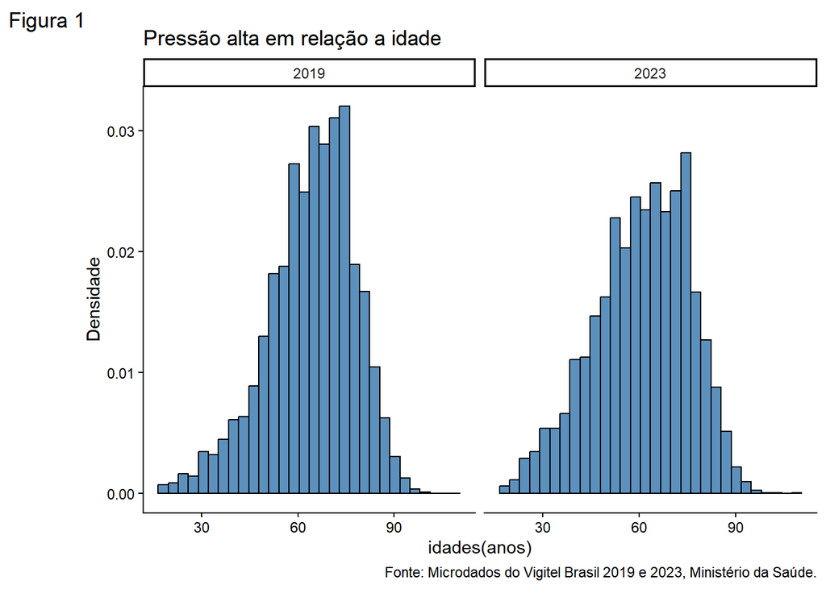

Nessa tabela o objetivo e comparar a média e a convalência de variância de cada ano com variáveis relacionada a saúde dos entrevistados.

**Tabela de análise descritiva de peso e doenças crônicas.**

|  | 2019 |  | 2023 |  |
| --- | --- | --- | --- | --- |
|  | x̄ | CV | x̄ | CV |
| peso | 71 | 21 | 73 | 22 |
| idade pressão alta | 64 | 21 | 60 | 24 |
| idade diabéticos | 66 | 18 | 62 | 21 |

Observando a **Figura 1** em comunhão com a tabela acima é possível notar a diferença entre a distribuição de densidade dos dados em 2019 com 2023. Onde vemos que em 2019 o gráfico é mais *“agudo”* (os dados estão concentrados em uma parcela das idades) e em 2023 ele é mais *disperso*, variando mais as idades. Observando a tabela, no ano de 2023 a média de idade dos entrevistados com pressão alta e diabete foi mais baixa que em 2019 e o coeficiente de variação calculada em 2023 foi mais alto que 2019 nas três variáveis, sendo possível ver esse aumento na dispersão dos dados também através da análise descritiva. E por fim a média do peso aumentou em 2023.

### 2.3 Análise do bem-estar da popolução dos entrevistados em momentos de lazer.

[interactive chart not shown]

No gráfico acima é notável uma mudança relevante na proporção de entrevistados que usam menos de 1 hora de tela em momentos de lazer, **em 2023 diminuiu 8% em comparação a 2019.**

[interactive chart not shown]

No gráfico acima a atividade física que mais se destaca é a musculação, e percebe-se que em 2023 ouve um aumento significativo de 11% nessa categoria em comparação ao ano de 2019.

## 3 Conclusão

### 3.1 Desafios e futuras análises

A minha dificuldade nessa base de dados: seu *tamanho*, onde eu tive que reduzir as variáveis e sacrificar algumas que não tinha nos dois anos,e a *limpeza da base* pois tinha muitos elementos e categorias que atrapalhavam no momento do estudo. Uma possibilidade para futuras análises é adicionar os próximos anos (pós-pandemia) e fazer um estudo de 2 em 2 anos com essas variáveis estudadas ou com outras da base original.[^5]

## 4 Referências

Brasil. Ministério da Saúde. Secretaria de Vigilância em Saúde. Departamento de Análise em Saúde e Vigilância de Doenças Não Transmissíveis. Vigitel Brasil 2019 : vigilância de fatores de risco e proteção para doenças crônicas por inquérito telefônico : estimativas sobre frequência e distribuição sociodemográfica de fatores de risco e proteção para doenças crônicas nas capitais dos 26 estados brasileiros e no Distrito Federal em 2019 [recurso eletrônico] / Ministério da Saúde, Secretaria de Vigilância em Saúde, Departamento de Análise em Saúde e Vigilância de Doenças não Transmissíveis. Disponível em: [https://svs.aids.gov.br/daent/cgdnt/vigitel/]. Acesso em: [abril de 2026].

Brasil. Ministério da Saúde. Secretaria de Vigilância em Saúde e Ambiente. Departamento de Análise Epidemiológica e Vigilância  
de Doenças Não Transmissíveis. Vigitel Brasil 2023: vigilância de fatores de risco e proteção para doenças crônicas por inquérito telefônico: estimativas sobre frequência e distribuição sociodemográfica de fatores de risco e proteção para doenças crônicas nas capitais dos 26 estados brasileiros e no Distrito Federal em 2023 [recurso eletrônico] / Ministério da Saúde, Secretaria de Vigilância em Saúde e Ambiente, Departamento de Análise Epidemiológica e Vigilância de Doenças Não Transmissíveis.Disponível em: [https://svs.aids.gov.br/daent/cgdnt/vigitel/]. Acesso em: [abril de 2026].

R version 4.5.3 (2026-03-11 ucrt) – “Reassured Reassurer” Copyright (C) 2026 The R Foundation for Statistical Computing Platform: x86_64-w64-mingw32/x64

Wickham H, Averick M, Bryan J, Chang W, McGowan LD, François R, Grolemund G, Hayes A, Henry L, Hester J, Kuhn M, Pedersen TL, Miller E, Bache SM, Müller K, Ooms J, Robinson D, Seidel DP, Spinu V, Takahashi K, Vaughan D, Wilke C, Woo K, Yutani H (2019). “Welcome to the tidyverse.” *Journal of Open Source Software*, *4*(43), 1686. doi:10.21105/joss.01686 https://doi.org/10.21105/joss.01686.

C. Sievert. Interactive Web-Based Data Visualization with R, plotly, and shiny. Chapman and Hall/CRC Florida, 2020.

Xie Y (2025). *knitr: A General-Purpose Package for Dynamic Report Generation in R*. R package version 1.51, https://yihui.org/knitr/.

Arnold J (2025). *ggthemes: Extra Themes, Scales and Geoms for ‘ggplot2’*. R package version 5.2.0, https://jrnold.github.io/ggthemes/.

Bissoli S (2025). *healthbR: Access Brazilian Public Health Data*. R package version 0.2.0, https://github.com/SidneyBissoli/healthbR.

## Footnotes

[^1]: **Bissoli S (2025). healthbR: Acesse Dados de Saúde Pública do Brasil. Pacote R versão 0.2.0**, https://github.com/SidneyBissoli/healthbR.
[^2]: Nessa váriavel a três categorias possíveis de resposta : “não consumo”, “sim”, “sim,mas não no último mês”.Nessa análise eu escolhi priorizar somente à categoria:“sim”.
[^3]: mesmo sendo uma grande quantidade de entrevistados esses resultados não podem ser considerados para a população brasileira pois eles foram coletados **somente** em capitais dos estados e Distrito Federal.
[^4]: mesmo sendo uma grande quantidade de entrevistados esses resultados não podem ser considerados para a população brasileira pois eles foram coletados **somente** em capitais dos estados e Distrito Federal.
[^5]: já que todos anos eles fazem essa pesquisa.